# Used Cars Pricing Modeling

Reese Karo

2024-02-20

- To refer to a Python EDA over a similar (but not the same) data set, https://medium.com/mlearning-ai/detailed-exploratory-data-analysis-eda-on-used-cars-data-1bacac746ff4

# EDA intro

In this document we will be exploring our data and using visuals (graphs, plots, and tables) to help explain how our data can be transformed into clean, processable data to begin modeling.

```r
library(tidyverse)
library(tidymodels)
library(ggplot2)
library(corrplot)
library(ggthemes)
library(dplyr)
tidymodels_prefer()

car_data <- read.csv('/Users/reese/Documents/School/UC Santa Barbra /Junior/Winter/131/Project/car_prices.csv')
head(car_data)
```

```
##   year   make               model       trim  body transmission
## 1 2015    Kia             Sorento         LX   SUV    automatic
## 2 2015    Kia             Sorento         LX   SUV    automatic
## 3 2014    BMW            3 Series 328i SULEV Sedan    automatic
## 4 2015  Volvo                 S60         T5 Sedan    automatic
## 5 2014    BMW 6 Series Gran Coupe       650i Sedan    automatic
## 6 2015 Nissan              Altima      2.5 S Sedan    automatic
##                 vin state condition odometer color interior
## 1 5xyktca69fg566472    ca         5    16639 white    black
## 2 5xyktca69fg561319    ca         5     9393 white    beige
## 3 wba3c1c51ek116351    ca       4.5     1331  gray    black
## 4 yv1612tb4f1310987    ca       4.1    14282 white    black
## 5 wba6b2c57ed129731    ca       4.3     2641  gray    black
## 6 1n4al3ap1fn326013    ca         1     5554  gray    black
##                                               seller   mmr sellingprice
## 1                            kia motors america, inc 20500        21500
## 2                            kia motors america, inc 20800        21500
## 3             financial services remarketing (lease) 31900        30000
## 4                            volvo na rep/world omni 27500        27750
## 5             financial services remarketing (lease) 66000        67000
## 6 enterprise vehicle exchange / tra / rental / tulsa 15350        10900
##                                  saledate
## 1 Tue Dec 16 2014 12:30:00 GMT-0800 (PST)
## 2 Tue Dec 16 2014 12:30:00 GMT-0800 (PST)
## 3 Thu Jan 15 2015 04:30:00 GMT-0800 (PST)
## 4 Thu Jan 29 2015 04:30:00 GMT-0800 (PST)
## 5 Thu Dec 18 2014 12:30:00 GMT-0800 (PST)
## 6 Tue Dec 30 2014 12:00:00 GMT-0800 (PST)
```

## Data Mutation

- we first need to see what our data consists of. We can use the ‘summary()’ function

```r
summary(car_data)
```

```
##      year               make              model               trim
##  Length:558863      Length:558863      Length:558863      Length:558863
##  Class :character   Class :character   Class :character   Class :character
##  Mode  :character   Mode  :character   Mode  :character   Mode  :character
##
##
##
##
##      body           transmission           vin               state
##  Length:558863      Length:558863      Length:558863      Length:558863
##  Class :character   Class :character   Class :character   Class :character
##  Mode  :character   Mode  :character   Mode  :character   Mode  :character
##
##
##
##
##   condition            odometer         color             interior
##  Length:558863      Min.   :     1   Length:558863      Length:558863
##  Class :character   1st Qu.: 28371   Class :character   Class :character
##  Mode  :character   Median : 52254   Mode  :character   Mode  :character
##                     Mean   : 68320
##                     3rd Qu.: 99109
##                     Max.   :999999
##                     NA's   :120
##     seller              mmr             sellingprice      saledate
##  Length:558863      Length:558863      Min.   :     1   Length:558863
##  Class :character   Class :character   1st Qu.:  6900   Class :character
##  Mode  :character   Mode  :character   Median : 12100   Mode  :character
##                                        Mean   : 13611
##                                        3rd Qu.: 18200
##                                        Max.   :230000
##                                        NA's   :26
```

```r
table(car_data$transmission)
```

```
##
##           automatic    manual     sedan     Sedan
##     65379    475914     17544        15        11
```

```r
## changing the sedan transmissions to automatic because they were all automatic transmissions
car_data <- car_data %>%
  mutate(
    transmission = ifelse(tolower(transmission) == "sedan", "automatic", transmission),
    body = ifelse(tolower(body) == "sedan", "sedan", body)
  )
```

```r
table(car_data$transmission)
```

```
##
##           automatic    manual
##     65379    475940     17544
```

Now there are 0 sedan transmissions. Also by viewing the data set, we see that Transmission data is also missing some observations in the sense that some observations do not have values that fall in “automatic” or “manual”. We can fix this by either imputing values when creating the recipe by KNN or another method, or by removing some observations, which will be the least likely choice.

### Changing all the makes, models, trims, and body styles to lowercase for matching cases

```r
car_data <- car_data %>%
  mutate(
    make = tolower(make),
    model = tolower(model),
    trim = tolower(trim),
    body = tolower(body)
  )
```

### reviewing the tables again, but for viewing the document, I have commented them out.

```r
# uncomment to see the tables
#table(car_data$make)
#table(car_data$transmission)
#table(car_data$body)
#table(car_data$trim)
```

- We need to clean up the data so State and VIN and condition don’t have the wrong data or data in the wrong columns. This is so that we can transform the data and find a correlation of condition and price and odometer

```r
state_vin_list <- c("3vwd17aj0fm227318", "3vwd17aj2fm258506", "3vwd17aj2fm261566" ,"3vwd17aj2fm285365", "3vwd17aj3fm259017", "3vwd17aj3fm276741", "3vwd17aj4fm201708","3vwd17aj4fm236636", "3vwd17aj5fm206111", "3vwd17aj5fm219943", "3vwd17aj5fm221322", "3vwd17aj5fm225953", "3vwd17aj5fm268964", "3vwd17aj5fm273601","3vwd17aj5fm297123", "3vwd17aj6fm218641", "3vwd17aj6fm231972", "3vwd17aj7fm218440", "3vwd17aj7fm222388", "3vwd17aj7fm223475", "3vwd17aj7fm229552", "3vwd17aj7fm326640", "3vwd17aj8fm239622", "3vwd17aj8fm298895", "3vwd17aj9fm219766", "3vwd17ajxfm315938")
filtered_data <- car_data %>%
  filter(make == "volkswagen", model == "jetta", state %in% state_vin_list)
# filtered_data - uncomment to view the filtered data
```

```r
# and assuming these values are mistakenly placed in the 'state' column
car_data_cleaned <- car_data %>%
  filter(!(state %in% state_vin_list)) %>%
  filter(state != "")

# Display the table for the 'state' column after removal
# table(car_data_cleaned$state)
```

### Converting character columns to numeric columns

```r
table(car_data_cleaned$condition)
```

```
##
##           1   1.1   1.2   1.3   1.4   1.5   1.6   1.7   1.8   1.9     2   2.1
## 11794  7364    87    95    82   134   144   178   243   323 42281 20790  9199
##   2.2   2.3   2.4   2.5   2.6   2.7   2.8   2.9     3   3.1   3.2   3.3   3.4
##  6057  8188  9326 12561 11912 16351 19178 18928 10803  9222  9962 10619 17398
##   3.5   3.6   3.7   3.8   3.9     4   4.1   4.2   4.3   4.4   4.5   4.6   4.7
## 26750 23144 25938 18723 19920 19922 23073 24328 24937 25514 12313 12634 11363
##   4.8   4.9     5
## 12712 13099 11222
```

```r
typeof(car_data_cleaned$condition)
```

```
## [1] "character"
```

```r
car_data_cleaned$condition <- as.numeric(car_data_cleaned$condition)
car_data_cleaned$mmr <- as.integer(car_data_cleaned$mmr)
car_data_cleaned$odometer <- as.integer(car_data_cleaned$odometer)
```

### Summarizng missing data

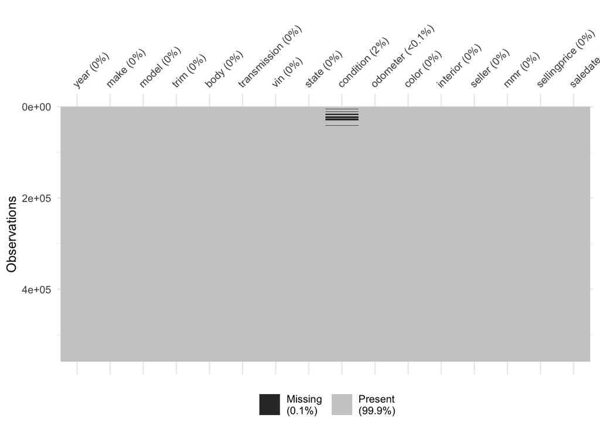

```r
library(naniar)
vis_miss(car_data_cleaned, warn_large_data = F)
```

### Viewing the observations with no transmission written down.

```r
library(dplyr)
car_data_cleaned %>%
  filter(transmission == "" & is.na(condition)) %>% head()
```

```
##   year          make   model    trim  body transmission               vin state
## 1 2015       hyundai  sonata      se sedan              5npe24af4fh001562    ca
## 2 2014     chevrolet   cruze     1lt sedan              1g1pc5sb6e7128803    ca
## 3 2013 mercedes-benz m-class   ml350   suv              4jgda5jb6da160181    ca
## 4 2012          ford    flex limited wagon              2fmgk5dc5cbd10752    ca
## 5 2012          ford  escape limited   suv              1fmcu0eg0ckc81633    ca
## 6 2012     chevrolet  malibu      lt sedan              1g1zd5e07cf310660    ca
##   condition odometer  color interior                                  seller
## 1        NA     8311    red        —                                avis tra
## 2        NA    38261  white        —                                avis tra
## 3        NA    32532                               trade in solutions irvine
## 4        NA    53527 silver        — onemain rem/manheim southern california
## 5        NA    21072  black        —                           carmax # 7159
## 6        NA    63220   gold        —                   the hertz corporation
##     mmr sellingprice                                saledate
## 1 15200         4200 Tue Dec 16 2014 13:00:00 GMT-0800 (PST)
## 2 11450         2000 Tue Dec 16 2014 13:00:00 GMT-0800 (PST)
## 3 36100        34500 Tue Dec 16 2014 12:30:00 GMT-0800 (PST)
## 4 19350        16750 Thu Dec 18 2014 12:00:00 GMT-0800 (PST)
## 5 17550        13400 Wed Dec 17 2014 12:30:00 GMT-0800 (PST)
## 6  9450         9500 Tue Dec 16 2014 12:30:00 GMT-0800 (PST)
```

```r
car_data_cleaned %>%
  filter(is.na(condition)) %>% head()
```

```
##   year      make  model      trim        body transmission               vin
## 1 2014 chevrolet  cruze       2lt       sedan    automatic 1g1pe5sbxe7120097
## 2 2015   hyundai sonata        se       sedan              5npe24af4fh001562
## 3 2014 chevrolet camaro        lt convertible    automatic 2g1fb3d31e9134662
## 4 2015   hyundai sonata        se       sedan    automatic 5npe24af4fh038482
## 5 2014       bmw     x5 sdrive35i         suv    automatic 5uxkr2c52e0h33130
## 6 2015   hyundai sonata        se       sedan    automatic 5npe24af2fh014813
##   state condition odometer  color interior
## 1    ca        NA    15686   blue    black
## 2    ca        NA     8311    red        —
## 3    ca        NA    33450  black    black
## 4    ca        NA     9281 silver     gray
## 5    ca        NA    11278   gray    black
## 6    ca        NA     9208 silver     gray
##                                               seller   mmr sellingprice
## 1                               avis rac/san leandro 13900        10600
## 2                                           avis tra 15200         4200
## 3                               avis rac/san leandro 20100        14700
## 4 enterprise vehicle exchange / tra / rental / tulsa 15150         8500
## 5                               avis rac/san leandro 50400        34000
## 6 enterprise vehicle exchange / tra / rental / tulsa 15700        10000
##                                  saledate
## 1 Tue Dec 16 2014 12:00:00 GMT-0800 (PST)
## 2 Tue Dec 16 2014 13:00:00 GMT-0800 (PST)
## 3 Tue Dec 16 2014 12:00:00 GMT-0800 (PST)
## 4 Tue Dec 16 2014 13:00:00 GMT-0800 (PST)
## 5 Tue Dec 16 2014 13:00:00 GMT-0800 (PST)
## 6 Thu Dec 18 2014 12:00:00 GMT-0800 (PST)
```

### Avg pricing for each make

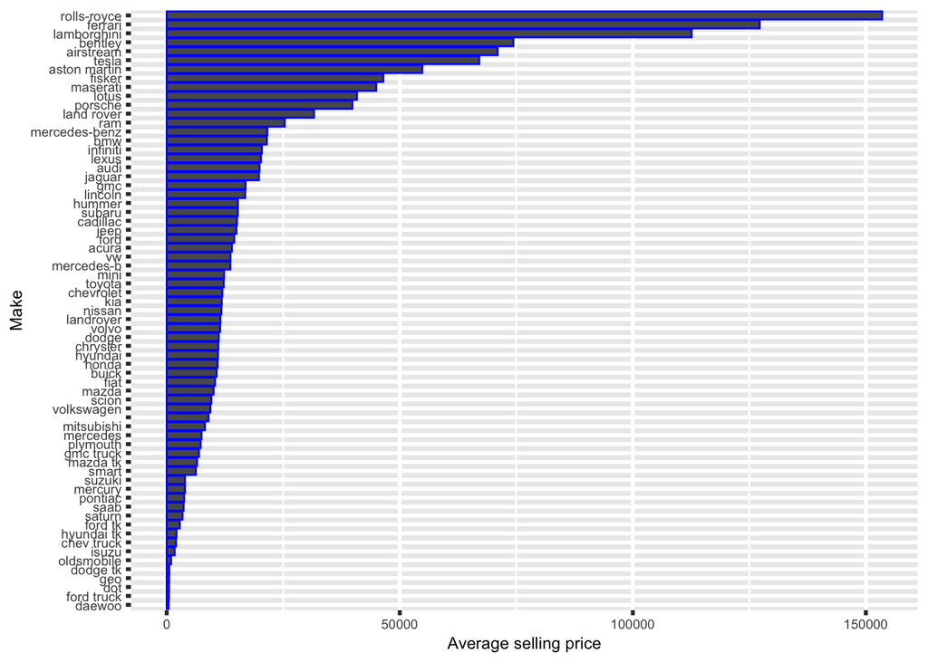

```r
### summarizing the sell prices of each make
car_sorted_byprice <- car_data_cleaned %>%
  group_by(make) %>% # grouping by the make
  summarise(avg_sell_price = mean(sellingprice, na.rm = TRUE)) %>% # summarizing by the mean of the selling price and removing null obs
  arrange(desc(avg_sell_price)) # descending avg selling price

### plotting using a bar chart
barplot_sorted <- ggplot(car_sorted_byprice, aes(x = reorder(make, avg_sell_price), y = avg_sell_price)) +
  geom_bar(stat = "identity", color = "blue") +
  coord_flip() +
  labs(x= "Make", y = "Average selling price") +
  theme(text = element_text(size = 9),element_line(size =1))

barplot_sorted
```

## top 10 selling cars

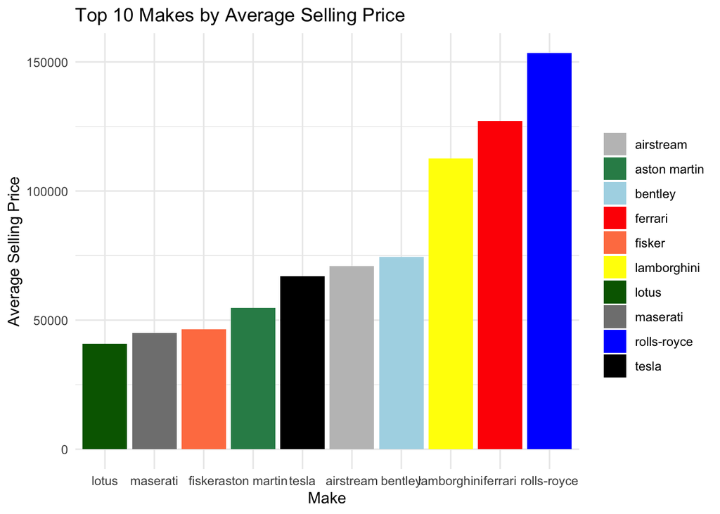

```r
library(ggplot2)
library(dplyr)
### summarizing the sell prices of each make for the top 10 makes
car_sorted_byprice <- car_data_cleaned %>%
  group_by(make) %>%
  summarise(avg_sell_price = mean(sellingprice, na.rm = TRUE)) %>%
  arrange(desc(avg_sell_price)) %>%
  top_n(10, avg_sell_price)
# Selecting the colors for the graph
colors <- c(
  "lotus" = "#006400", # Dark green
  "maserati" = "#808080", # Grey
  "fisker" = "#FF7F50", # coral
  "aston martin" = "#2E8B57", # Seagreen
  "tesla" = "#000000", # Black
  "airstream" = "#C0C0C0", # Silver
  "bentley" = "#add8e6", # light blue
  "lamborghini" = "#FFFF00", # Yellow
  "ferrari" = "#FF0000", # Red
  "rolls-royce" = "#0000FF" # Blue
)
### plotting using a bar chart
barplot_sorted <- ggplot(car_sorted_byprice, aes(x = reorder(make, avg_sell_price), y = avg_sell_price, fill = make)) +
  geom_bar(stat = "identity") +
  labs(title = "Top 10 Makes by Average Selling Price", x = "Make", y = "Average Selling Price") +
  scale_fill_manual(values = colors) +
  theme_minimal() +
  theme(legend.title = element_blank())

barplot_sorted
```

### Correlation plot of numerical data

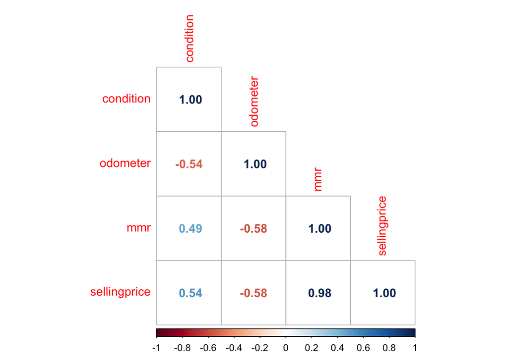

```r
library(corrplot)
# using only numeric data from the cleaned car data
numeric_car_data <- car_data_cleaned %>% select(is.numeric)
# creating a corr matrix to be displayed by using complete observations
cor_car_matrix <- cor(numeric_car_data, use = "complete.obs")
# corr plot with numbers shown
corrplot(cor_car_matrix, method = "number", type = "lower", diag = T)
```

From the correlation plot, we can see there is positive correlation between the mmr and condition, as well as the selling price and the condition. This can be interpreted as when the car sells for more or the mmr is higher, the condition will be higher. For the odometer (mileage) of the car, we can view this as negative correlation, or interpreted as, lower mileage indicates a higher condition number (or a higher mileage and lower condition number).

### Transmission Types versus Selling Price

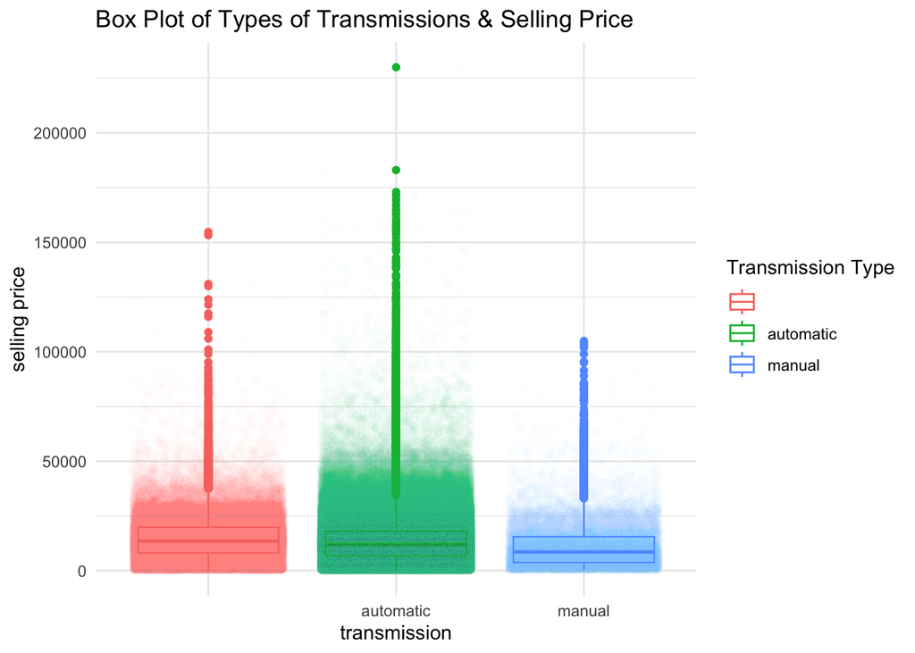

```r
# creating a box plot for the transmissions
car_data_cleaned %>%
  ggplot(aes(x = transmission, y = sellingprice, color = transmission)) +
  geom_boxplot() +
  geom_jitter(alpha = 0.01) +
  labs(title = "Box Plot of Types of Transmissions & Selling Price", x = "transmission", y = "selling price", color = "Transmission Type") +
  theme_minimal()
```

From this plot we can see that most of the cars selling for each transmission is below the $50,000 selling price mark. This graph also shows that there are fewer cars with manual transmissions that sell.

### Selling Price and Odometer distribution curves

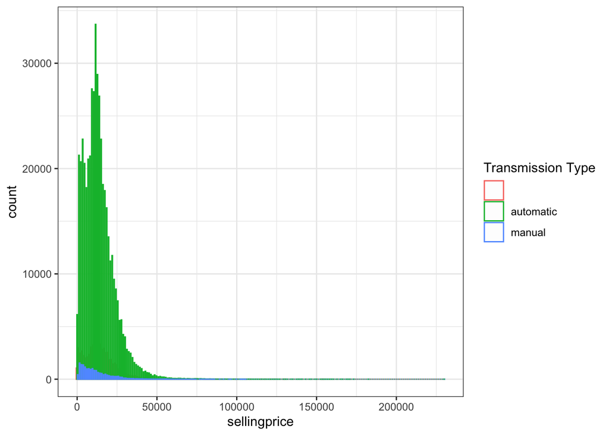

```r
ggplot(aes(x = sellingprice, color = transmission), data = car_data_cleaned) +
  geom_histogram(bins = 200, alpha = 0.01, position = "dodge") +
  labs(color = "Transmission Type") +
  theme_bw()
```

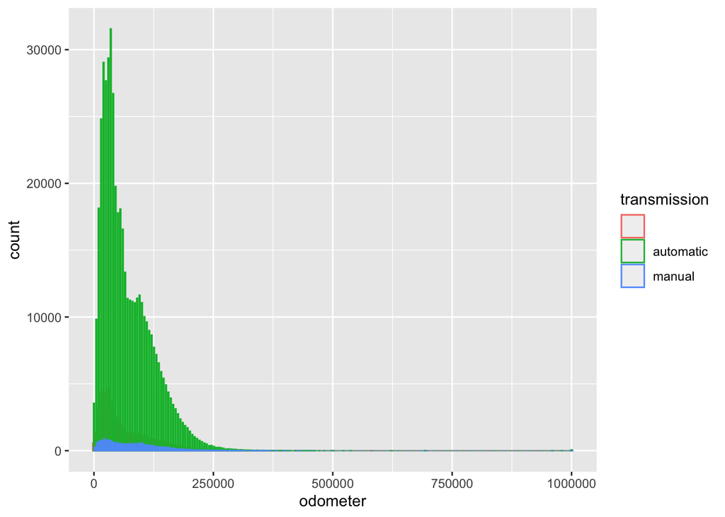

```r
ggplot(aes(x = odometer, color = transmission), data = car_data_cleaned) +
  geom_histogram(bins = 200, alpha = 0.01, position = "dodge")
```

### Condition of Cars vs the Color

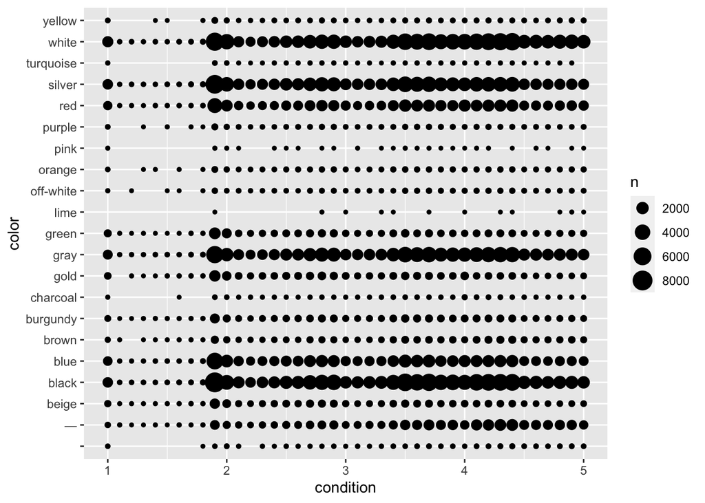

```r
# represents and shows the relationship between condition and color of the cars
ggplot(car_data_cleaned, aes(x = condition, y = color)) +
  geom_count()
```

This shows us that Cars in white, silver, gray, and black are the most popular and we can see that their conditions are dense around 2 - 4.5.

### Selling cars per state

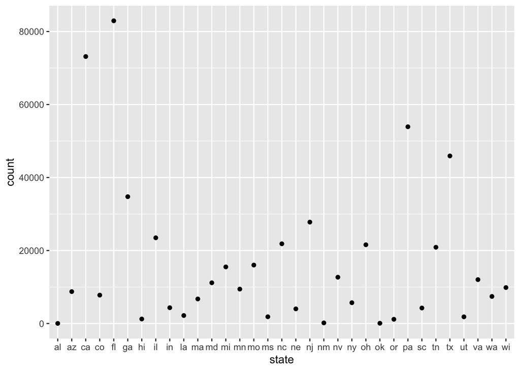

```r
library(dplyr)
library(sf)
library(tidyverse)


# to remove cars with no state we will filter through them, and summarize the data.
car_data_cleaned_state <- car_data_cleaned %>%
  filter(state != "") %>%
  group_by(state) %>%
  summarise(count = n())

# ensure state abbreviations are lower case to match the data sets 'state' abbreviations
lowercase_state <- tolower(state.abb)

states_info <- tibble(abbreviation = lowercase_state, full_name = state.name)

# Join car data with this lookup to get the full state name
car_data_with_name <- car_data_cleaned_state %>%
  left_join(states_info, by = c("state" = "abbreviation"))

usa_with_cars_filtered <- car_data_with_name %>% # we are filtering out states that are not filed into the right state.
  filter(!is.na(full_name)) %>%
  group_by(state) %>%
  arrange(desc(count))

usa_with_cars_filtered %>%
  ggplot(aes(x=state, y = count)) +
  geom_point()
```

This scatter plot or point plot will allow us to visualize where the cars are being sold from. We can see that Florida has the highest number of selling cars followed by California, Pennsylvania, Texas, and Georgia.

### Odometer versus Selling Price

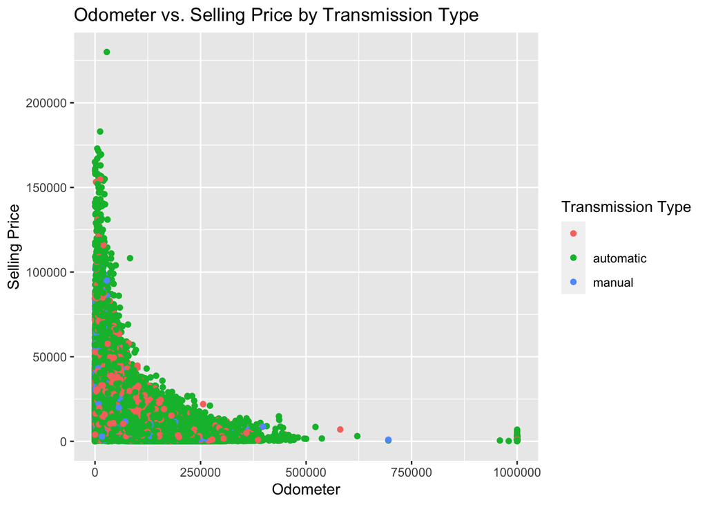

```r
car_data_cleaned %>%
  ggplot(aes(x = odometer, y = sellingprice, color = transmission)) +
  geom_point() +
  labs(title = "Odometer vs. Selling Price by Transmission Type",
       x = "Odometer",
       y = "Selling Price",
       color = "Transmission Type")
```